# Ch16Practice

Justine

2021/7/3

# Home

### 是非題

1.(X)我們可以使用install( )函數來下載所需要的擴展包  
2.(X)常被用來獲得數據集中趨勢的R函數有三種：mean(), median()與mode()  
3.(X)R程式求取標準差的函數為stdev()  
4.(O)有2個指令如下：  
> x <- c(3,3,3,2,2,1)  
> unique(x)  
上述指令執行結果如下：  
[1] 3 2 1

```r
x <- c(3,3,3,2,2,1)
unique(x)
```

```
## [1] 3 2 1
```

5.(O)我們可以用quantile()函數同時取得第1四分位數、第2四分位數以及第3四分位數  
6.(O)有1個指令如下：  
> quantile(1:7)  
上述指令執行結果如下：  
0% 25% 50% 75% 100%  
1.0 2.5 4.0 5.5 7.0

```r
quantile(1:7)
```

```
##   0%  25%  50%  75% 100%
##  1.0  2.5  4.0  5.5  7.0
```

7.(O)R可以使用table()函數去取得數據出現的次數或稱頻率  
8.(X)R可以使用hist()函數去繪製直方圖，若使用參數nbreaks =10，表示指定柱狀的數量為10  
9.(O)R語言有提供一個密度函數density()，可以將欲建圖表的數據利用這個函數轉成一個密度物件串列(List)，未來可將這個物件放入plot( )函數內就可以繪製密度圖  
10.(O)若使用mycar數據框物件繪製汽缸數(cyl)對油耗(mpg)之間的箱型比較圖。可以使用以下的R指令：  
> boxplot(mpg~cyl,data = mycar)

### 選擇題

1.(D)以下哪ㄧ個不是正確的求取數據集中趨勢的函數？  
(A)mean() (B)median()  
(C)所列三個函數都是 (D)mode()  
2.(C)R程式求取標準差的函數為何？  
(A)stdev() (B)std() (C)sd() (D)dev()  
3.(C)以下指令會得到何數值結果？  
> x <- c(3,3,3,2,2,1)  
> length(unique(x))  
(A)[1] 1 (B)[1] 6 (C)[1] 3 (D)[1] 0

```r
x <- c(3,3,3,2,2,1)
length(unique(x))
```

```
## [1] 3
```

4.(B)以下指令會得到何結果？  
> x <- c(1,1,1,1,2,2,3)  
> table(x)  
(A)[1] 1 2 3  
(B)x  
1 2 3  
4 2 1  
(C)x  
1 2 3  
1 2 3  
(D)[1] 1 4 2 2 3 1

```r
x <- c(1,1,1,1,2,2,3)
table(x)
```

```
## x
## 1 2 3
## 4 2 1
```

5.(A)以下指令會得到何結果?  
> x <- c(1,1,1,1,2,2,3,4)  
> tx <- table(x)  
> index <- tx == max(tx)  
> names(tx[index])  
(A)[1]“1” (B)[1]“2” (C)[1]“3” (D)[1]“4”

```r
x <- c(1,1,1,1,2,2,3,4)
tx <- table(x)
index <- tx == max(tx)
names(tx[index])
```

```
## [1] "1"
```

6.(C)以下指令會得到何數值結果?  
> x <- c(1,1,1,1,2,2,3,4)  
> which.max(x) (A)[1] 1 (B)[1] 4 (C)[1] 8 (D)[1] 6

```r
x <- c(1,1,1,1,2,2,3,4)
which.max(x)
```

```
## [1] 8
```

7.(B)給定x向量內容為(1, 2, 2, 3, 3, 3, 4, 4, 4, 4, 5, 5, 5, 6, 6, 7)，使用以 下何指令可以得到以下的統計圖?  
(A)> hist(x)  
> density(x)  
(B)> hist(x,freq=FALSE)  
> lines(density(x))  
(C)> plot(density(x))  
> hist(x)  
(D)> hist(x)  
> lines(density(x))

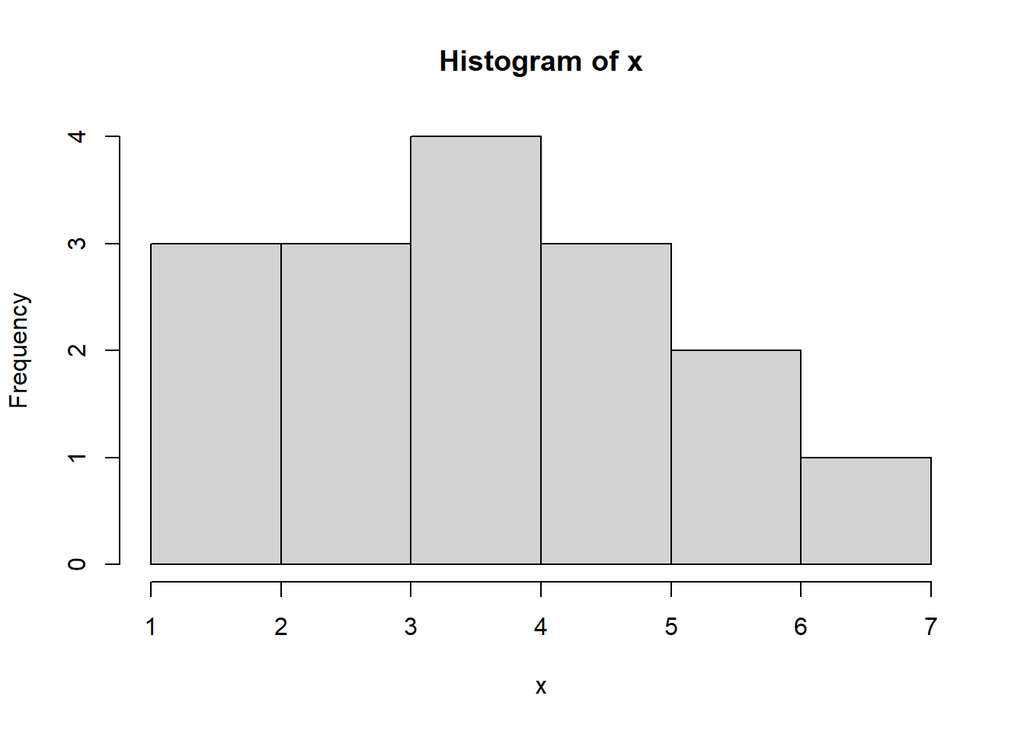

```r
x <- c(1, 2, 2, 3, 3, 3, 4, 4, 4, 4, 5, 5, 5, 6, 6, 7)
hist(x)
```

```r
density(x)
```

```
##
## Call:
##  density.default(x = x)
##
## Data: x (16 obs.);   Bandwidth 'bw' = 0.7715
##
##        x                y
##  Min.   :-1.315   Min.   :0.0003695
##  1st Qu.: 1.343   1st Qu.:0.0166587
##  Median : 4.000   Median :0.0840069
##  Mean   : 4.000   Mean   :0.0939741
##  3rd Qu.: 6.657   3rd Qu.:0.1659683
##  Max.   : 9.315   Max.   :0.2176453
```

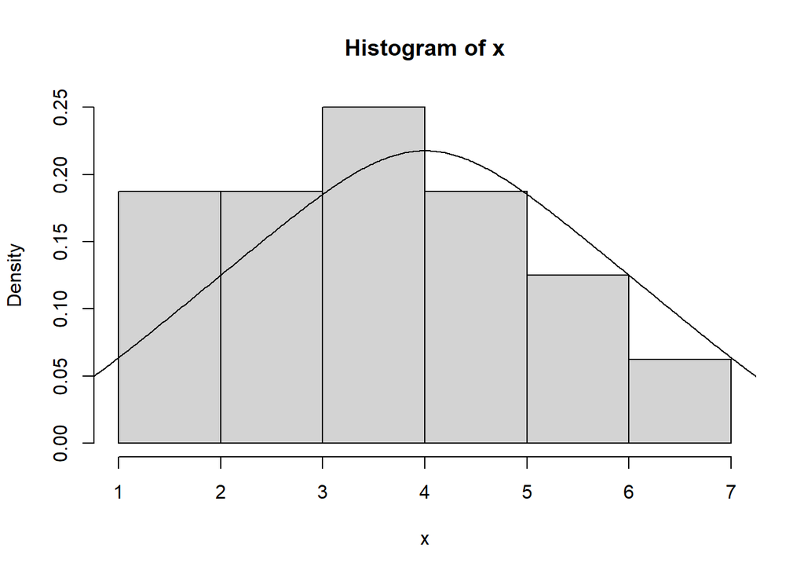

```r
hist(x,freq=FALSE)
lines(density(x))
```

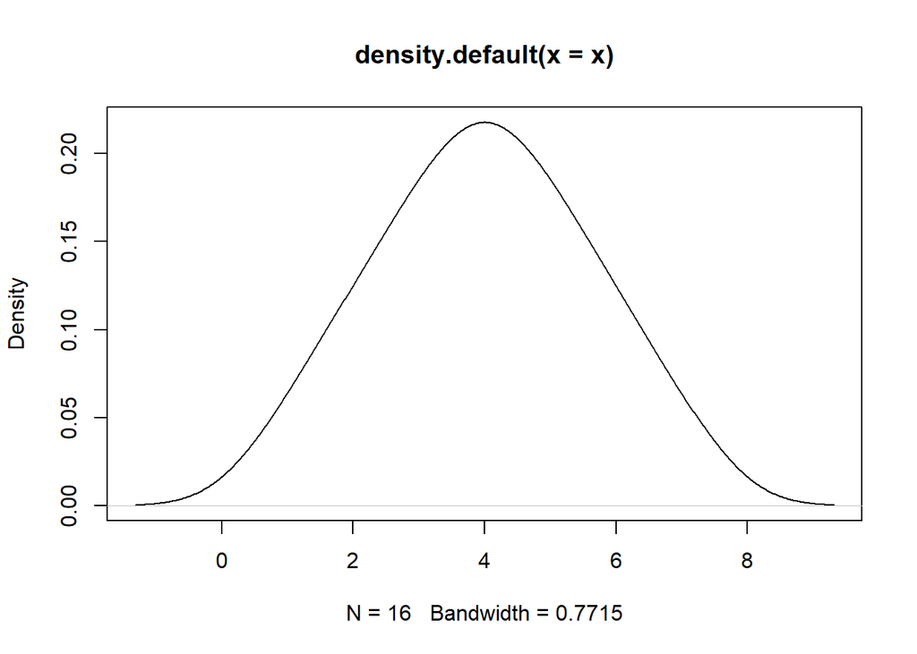

```r
plot(density(x))
```

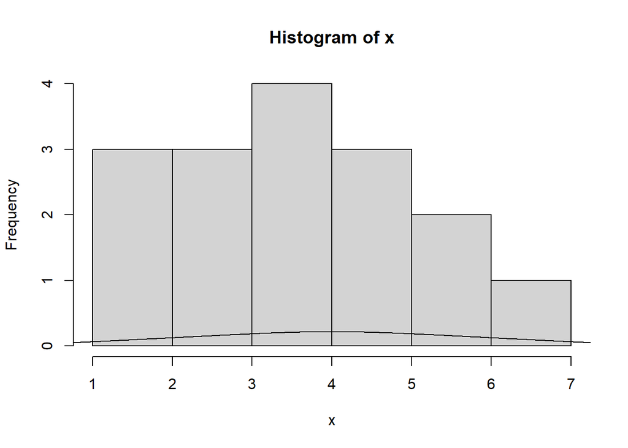

```r
hist(x)

hist(x)
lines(density(x))
```

9.(C)若兩個向量x與y執行了以下的指令與結果:  
> length(x)  
[1] 10  
> cor(x,y)  
[1] -0.9006627  
可知兩向量之間的關係為何？  
(A)輕微的正線性相關 (B)強烈正線性相關  
(C)強烈負線性相關 (D)無法判斷線性相關性

### 複選題

1.(BD)以下何指令可以用來下載MASS擴充包?  
(A)> load(MASS) (B)> install.packages“(MASS)”  
(C)> download(MASS) (D)> library(MASS) (E)> install(MASS)  
2.(DE)summary()函數所提供的結果中不包含以下何種統計值?  
(A)mean (B)3rd. Qu.  
(C)median (D)mode (E)var  
—

### 實作題

1.以rnorm(100,mean=60,sd=12)產生100筆平均數為60標準差為12的常態分配 隨機數向量x，並計算出x的平均數、中位數、眾數、變異數、標準差、全距、最大值、最小值、第一四分位數、第三四分位數等各項統計

```r
x<-rnorm(100,mean=60,sd=12)
mean(x)
```

```
## [1] 59.50944
```

```r
median(x)
```

```
## [1] 58.43434
```

```r
var(x)
```

```
## [1] 132.3878
```

```r
sd(x)
```

```
## [1] 11.50599
```

```r
range(x)
```

```
## [1] 31.88498 92.39714
```

```r
max(x)
```

```
## [1] 92.39714
```

```r
min(x)
```

```
## [1] 31.88498
```

```r
quantile(x)
```

```
##       0%      25%      50%      75%     100%
## 31.88498 50.72986 58.43434 67.25254 92.39714
```

2.建立上題x的直方圖並加上密度圖

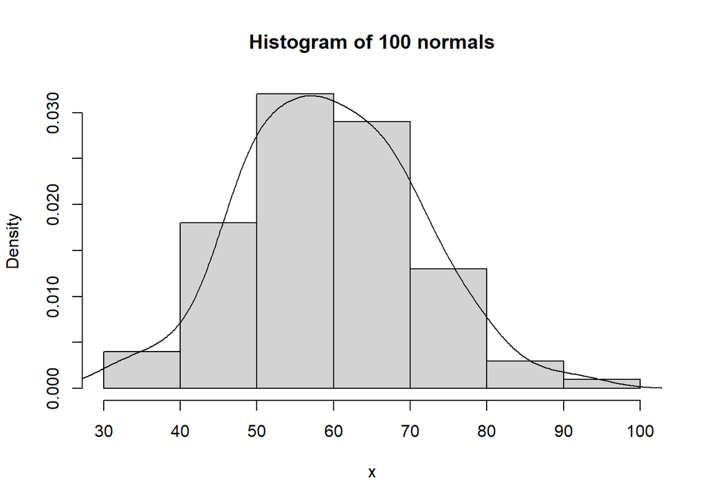

```r
hist(x,main = "Histogram of 100 normals",freq=FALSE)
lines(density(x))
```

3.使用summary( )函數以了解前題的向量x的各項總結統計並繪製其箱型圖

```r
summary(x)
```

```
##    Min. 1st Qu.  Median    Mean 3rd Qu.    Max.
##   31.88   50.73   58.43   59.51   67.25   92.40
```

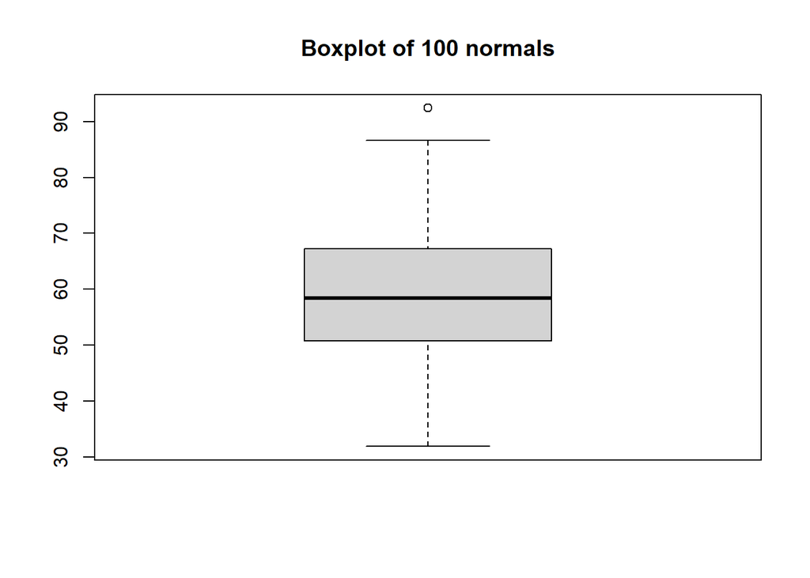

```r
boxplot(x,main = "Boxplot of 100 normals")
```

4.以rchisq(100, df=8)產生100筆自由度為8卡方分配的隨機向量y a.求取各項統計

```r
y<-rchisq(100, df=8)
mean(y)
```

```
## [1] 7.422797
```

```r
median(y)
```

```
## [1] 7.06257
```

```r
var(y)
```

```
## [1] 15.75149
```

```r
sd(y)
```

```
## [1] 3.968815
```

```r
range(y)
```

```
## [1]  1.10196 21.06235
```

```r
max(y)
```

```
## [1] 21.06235
```

```r
min(y)
```

```
## [1] 1.10196
```

```r
quantile(y)
```

```
##        0%       25%       50%       75%      100%
##  1.101960  4.164060  7.062570  9.812651 21.062347
```

b.繪製直方圖加密度圖

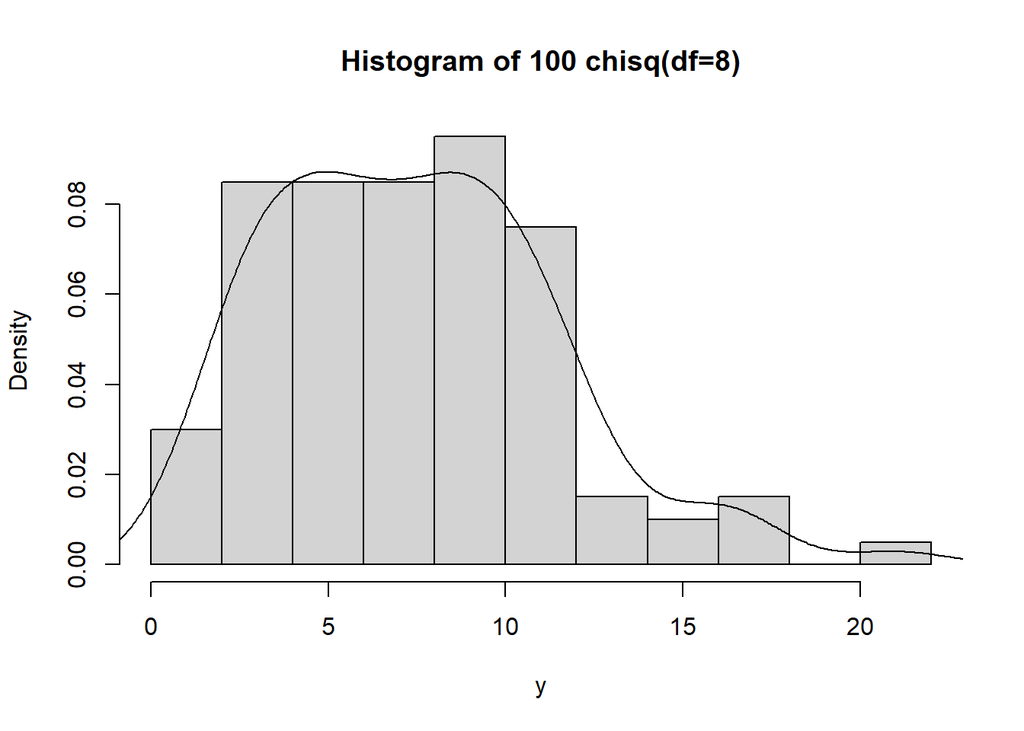

```r
hist(y,main = "Histogram of 100 chisq(df=8)",freq=FALSE)
lines(density(y))
```

c.套用summary()函數並繪製箱型圖

```r
summary(y)
```

```
##    Min. 1st Qu.  Median    Mean 3rd Qu.    Max.
##   1.102   4.164   7.063   7.423   9.813  21.062
```

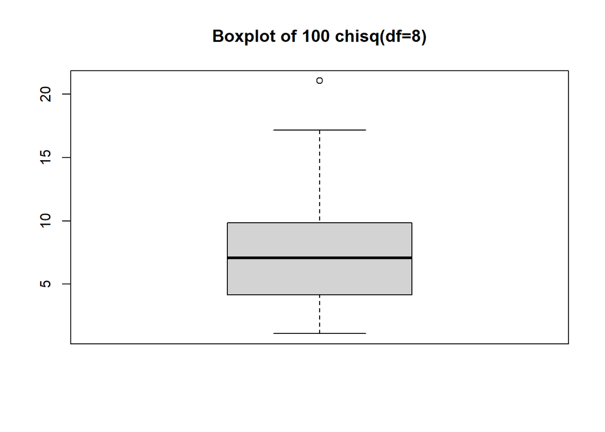

```r
boxplot(y,main = "Boxplot of 100 chisq(df=8)")
```

5.檢討上述題目所產生的x與y兩向量間的線性相關係數

```r
cor(x,y)
```

```
## [1] -0.08673151
```